# Задание 3. Прогнозирование показателей магазинов на 30 ноября 2015

Дмитрий Бодунов

29 октября 2016 г

Задача - восстановить данные за 2015-11-30. Рассчитать продажи, количество чеков и средний чек магазинов за этот день.

Для прогнозирование будем использовать модели, работающие с временными рядами. Использовать методы машинного обучения нецелесообразно, ввиду малого количества данных и отсуствия информации о длительный трендах и циклах. В качестве моделей рассмотрим две модели:

- ARIMA с учетом сезонности
- Экспоненциальное сглаживание Хольта-Винтерса

Данные по продажам и количеству чеков будем рассматривать в разрезе дней как временные ряды с сезонностью 7 дней.

#### **Среднее количество чеков**

В качестве первой величины рассмотрим среднее количество чеков в магазинах.

**Обучим модель ARIMA на наших данных:**

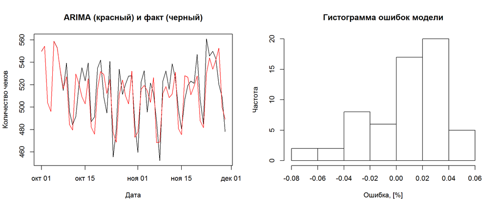

По гистограмме видно, что ошибки модели имеют не нормальное распределение. Рассчитаем среднюю процентную ошибку модели ARIMA (метрика MAPE):

| MAPE = 2.4% |
| --- |

**Обучим модель Хольта-Винтерса:**

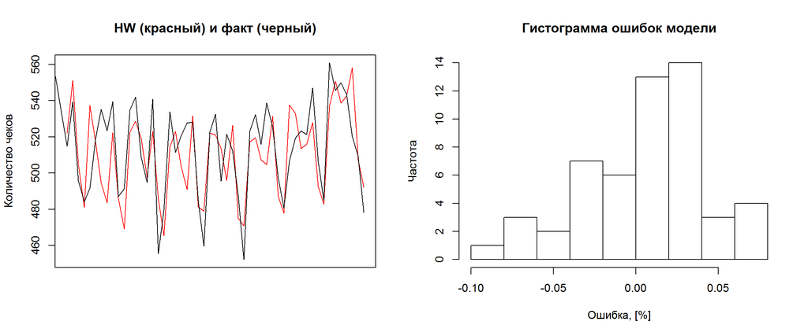

По гистограмме видно, что ошибки модели имеют не нормальное распределение. Рассчитаем среднюю процентную ошибку модели Хольта-Винтерса (метрика MAPE):

| MAPE = 2.9% |
| --- |

**Прогноз среднего количества чеков**

Из рассчитанных метрик следует, что модель ARIMA лучше рассчитывает среднее количество чеков в магазинах. Ее и будем ипользовать для прогнозирования. В общем случае для построения моделей следует использовать валидационную и тестовые выборки, но в данном случае данных слишком мало для подобного разбиения. Для выбора лучшей модели ARIMA использовался информационный критерий Акаике, который позволяет выбрать лучшую модель среди нескольких без тестовой выборки.

| Среднее количество чеков на 30.11.2015: 538 шт. |
| --- |

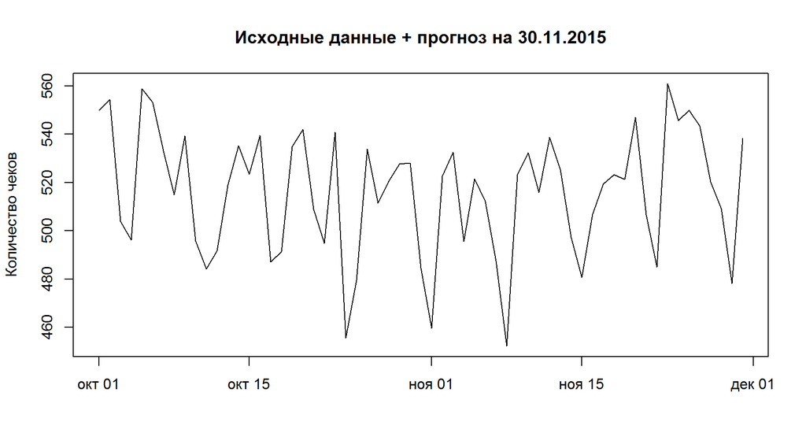

#### **Средние продажи**

Повторим все операции для прогнозирования средних продаж магазина.

**Обучим модель ARIMA на наших данных:**

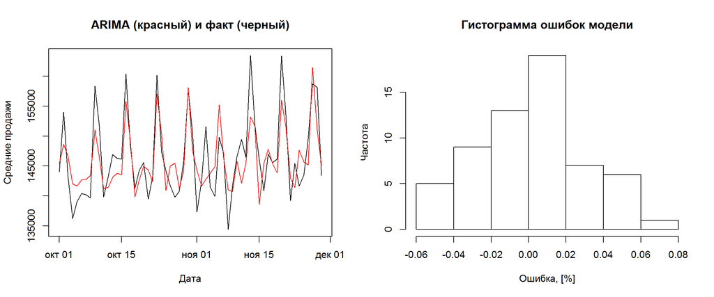

По гистограмме видно, что ошибки модели имеют не нормальное распределение. Рассчитаем среднюю процентную ошибку модели ARIMA (метрика MAPE):

| MAPE = 2.3% |
| --- |

**Обучим модель Хольта-Винтерса:**

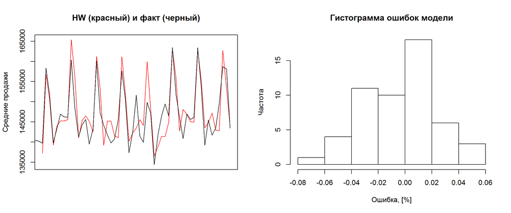

Рассчитаем среднюю процентную ошибку модели Хольта-Винтерса (метрика MAPE):

| MAPE = 2% |
| --- |

Из рассчитанных метрик следует, что модель Хольта-Винтерса лучше рассчитывает средние продажи в магазинах. Ее и будем ипользовать для прогнозирования.

| Средние продажи на 30.11.2015: 147130 руб. |
| --- |

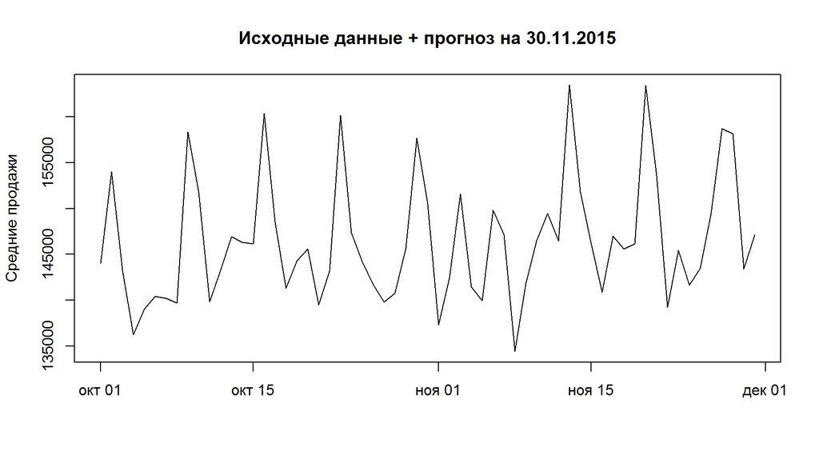

**Прогноз среднего чека**

Прогноз среднего чека рассчитаем как прогноз продаж деленный на прогноз количества чеков:

| Средний чек на 30.11.2015: 273.31 руб. |
| --- |

#### **Итог**

Прогноз искомых величин на 30.11.2015:

| Среднее количество чеков: 538 шт. |
| --- |

| Средние продажи: 147130 руб. |
| --- |

| Средний чек: 273.31 руб. |
| --- |